# Heart Failure Re-admission Project

2024-10-10

```r
# Load data
data <- read_excel("C:/Users/frazieg/Documents/HeartFailure/SHEET FOR ANALYSIS.xlsx")
glimpse(data)
```

```
## Rows: 1,048,575
## Columns: 36
## $ `ID 2`                                <chr> "EL 26/7/16", "WB 27/8/16", "PW …
## $ Age                                   <dbl> 84, 85, 62, 66, 67, 71, 71, 68, …
## $ SEX                                   <chr> "M", "M", "F", "M", "F", "M", "M…
## $ EDUCATIONAL                           <chr> "N/A", "N/A", "N/A", "N/A", "N/A…
## $ `Employment Status`                   <chr> "unemployed", "unemployed", "N/A…
## $ RELATIONSHIP                          <chr> "married", "single", "N/A", "mar…
## $ SMOKING                               <chr> "yes", "never", "N/A", "never", …
## $ `PACK YEARS`                          <chr> "40", "⁃", "⁃", "⁃", "⁃", "55", …
## $ `Past smoker`                         <chr> "yes- years", "⁃", "⁃", "⁃", "⁃"…
## $ `Current Smoker`                      <chr> "⁃", "⁃", "⁃", "⁃", "⁃", "⁃", "⁃…
## $ DRINKING                              <chr> "Yes", "never", "N/A", "yes", "n…
## $ YEARS                                 <chr> "30", "⁃", "⁃", "30", "⁃", "45",…
## $ `Past drinker`                        <chr> "yes", "⁃", "⁃", "yes- 1cup/day"…
```

[output cut: 23 more lines]

## Clean the dataset

```r
# Remove excess null rows
data <- data[1:201, ]

# Select relevant columns
data <- data %>%
  dplyr::select(ID_2 = `ID 2`, SEX, Age, SMOKING, DRINKING, COMPLIANCE, SURGERY, T2DM, HTN, Dyslipidemia, KidneyDisease, ASTHMACOPD, READMISSIONS)


glimpse(data)
```

```
## Rows: 201
## Columns: 13
## $ ID_2          <chr> "EL 26/7/16", "WB 27/8/16", "PW 27/8/16", "AW 13/4/18", …
## $ SEX           <chr> "M", "M", "F", "M", "F", "M", "M", "M", "F", "F", "M", "…
## $ Age           <dbl> 84, 85, 62, 66, 67, 71, 71, 68, 45, 59, 84, 64, 56, 65, …
## $ SMOKING       <chr> "yes", "never", "N/A", "never", "Never", "yes", "yes", "…
## $ DRINKING      <chr> "Yes", "never", "N/A", "yes", "never", "yes", "yes", "no…
## $ COMPLIANCE    <chr> "No", "Yes", "Yes", "No", "Yes", "No", "yes", "not state…
## $ SURGERY       <chr> "none", "yes", "yes", "yes", "yes", "none", "yes", "yes"…
## $ T2DM          <chr> "Y", "Y", "N", "N", "N", "N", "Y", "Y", "N", "Y", "N", "…
## $ HTN           <chr> "Y", "Y", "Y", "Y", "Y", "y", "N", "Y", "Y", "Y", "Y", "…
## $ Dyslipidemia  <chr> "N", "N", "N", "N", "Y", "Y", "N", "Y", "N", "N", "Y", "…
## $ KidneyDisease <chr> "Y", "N", "Y", "Y", "N", "N", "N", "N", "N", "N", "N", "…
## $ ASTHMACOPD    <chr> "N", "N", "N", "N", "N", "N", "Y", "N", "N", "N", "N", "…
## $ READMISSIONS  <dbl> 4, 3, 0, 0, 0, 3, 2, 2, 0, 3, 0, 2, 0, 3, 0, 3, 2, 0, 2,…
```

## Create Dummy variables

The dataset was created by a Pharmecutical student who was also the one that performed the survey, so the data was very raw and inconsistent. Letters were capitalized in some answers and not capitalized in others, some answers were “no” and then some answers were “none” for the same questions, along with other issues. The data had to be standardized and converted into dummy variables for easier analysis.

```r
# Create dummy variables and recode factors
data <- data %>%
  dplyr::mutate(across(c(SMOKING, DRINKING, COMPLIANCE, SURGERY, T2DM, HTN, ASTHMACOPD, Dyslipidemia, KidneyDisease),
                ~ case_when(.x == 'not stated' ~ NA_character_, .x == 'N/A' ~ NA_character_,
                            .x == 'never' | .x == 'Never' ~ '0',
                            .x == 'none' | .x == 'no' | .x == 'No' ~ '0',
                            .x == 'yes' | .x == 'Yes' | .x == 'YES' ~ '1',
                            .x == 'N' | .x == 'n' ~ '0',
                            .x == 'Y' | .x == 'y' ~ '1',
                            TRUE ~ .x))) %>%
  mutate(SEX = case_when(
    SEX == 'F' ~ '0',
    SEX == 'M' ~ '1',
    TRUE ~ SEX
  )) %>%
  replace_with_na_all(condition = ~.x %in% c("", "NA"))

data_clean <- na.omit(data)

# Create a binary variable for re-admission
data_clean <- data_clean %>%
  dplyr::mutate(Readmitted = ifelse(READMISSIONS >= 1, 1, 0))

glimpse(data)
```

```
## Rows: 201
## Columns: 13
## $ ID_2          <chr> "EL 26/7/16", "WB 27/8/16", "PW 27/8/16", "AW 13/4/18", …
## $ SEX           <chr> "1", "1", "0", "1", "0", "1", "1", "1", "0", "0", "1", "…
## $ Age           <dbl> 84, 85, 62, 66, 67, 71, 71, 68, 45, 59, 84, 64, 56, 65, …
## $ SMOKING       <chr> "1", "0", NA, "0", "0", "1", "1", "1", "0", "1", NA, "1"…
## $ DRINKING      <chr> "1", "0", NA, "1", "0", "1", "1", NA, "0", "0", NA, "1",…
## $ COMPLIANCE    <chr> "0", "1", "1", "0", "1", "0", "1", NA, "0", "0", "0", "0…
## $ SURGERY       <chr> "0", "1", "1", "1", "1", "0", "1", "1", "0", "1", "1", "…
## $ T2DM          <chr> "1", "1", "0", "0", "0", "0", "1", "1", "0", "1", "0", "…
## $ HTN           <chr> "1", "1", "1", "1", "1", "1", "0", "1", "1", "1", "1", "…
## $ Dyslipidemia  <chr> "0", "0", "0", "0", "1", "1", "0", "1", "0", "0", "1", "…
## $ KidneyDisease <chr> "1", "0", "1", "1", "0", "0", "0", "0", "0", "0", "0", "…
## $ ASTHMACOPD    <chr> "0", "0", "0", "0", "0", "0", "1", "0", "0", "0", "0", "…
## $ READMISSIONS  <dbl> 4, 3, 0, 0, 0, 3, 2, 2, 0, 3, 0, 2, 0, 3, 0, 3, 2, 0, 2,…
```

## Summary Statistics

This table shows the summary statistics for all the independent variables as well as the dependent variable “READMISSIONS”. Note that the “Age” variable is the only continuous variable while the other are categorical.

```r
Variables <- data[ ,c("Age", "SEX", "SMOKING", "DRINKING", "COMPLIANCE", "SURGERY", "T2DM",
                      "HTN", "Dyslipidemia", "KidneyDisease", "ASTHMACOPD", "READMISSIONS")]


print(summary_table <- dfSummary(Variables,
                           graph.col = TRUE,
                           valid.col = TRUE,
                           na.col = TRUE,
                           graph.magnif = 0.75,
                           style = "grid"),
      method = 'render')
```

Data Frame Summary

Variables

**Dimensions**: 201 x 12  
**Duplicates**: 0

| **No** | **Variable** | **Stats / Values** | **Freqs (% of Valid)** | **Graph** | **Valid** | **Missing** |
| --- | --- | --- | --- | --- | --- | --- |
| 1 | Age [numeric] | Mean (sd) : 61.8 (15.2) min ≤ med ≤ max: 27 ≤ 62 ≤ 94 IQR (CV) : 20 (0.2) | 62 distinct values |  | 201 (100.0%) | 0 (0.0%) |
| 2 | SEX [character] | 1. 0 2. 1 | 96 ( 47.8% ) 105 ( 52.2% ) |  | 201 (100.0%) | 0 (0.0%) |
| 3 | SMOKING [character] | 1. 0 2. 1 | 100 ( 60.2% ) 66 ( 39.8% ) |  | 166 (82.6%) | 35 (17.4%) |
| 4 | DRINKING [character] | 1. 0 2. 1 | 96 ( 61.1% ) 61 ( 38.9% ) |  | 157 (78.1%) | 44 (21.9%) |
| 5 | COMPLIANCE [character] | 1. 0 2. 1 | 91 ( 61.5% ) 57 ( 38.5% ) |  | 148 (73.6%) | 53 (26.4%) |
| 6 | SURGERY [character] | 1. 0 2. 1 | 69 ( 41.6% ) 97 ( 58.4% ) |  | 166 (82.6%) | 35 (17.4%) |
| 7 | T2DM [character] | 1. 0 2. 1 | 114 ( 56.7% ) 87 ( 43.3% ) |  | 201 (100.0%) | 0 (0.0%) |
| 8 | HTN [character] | 1. 0 2. 1 | 43 ( 21.4% ) 158 ( 78.6% ) |  | 201 (100.0%) | 0 (0.0%) |
| 9 | Dyslipidemia [character] | 1. 0 2. 1 | 156 ( 77.6% ) 45 ( 22.4% ) |  | 201 (100.0%) | 0 (0.0%) |
| 10 | KidneyDisease [character] | 1. 0 2. 1 | 151 ( 75.1% ) 50 ( 24.9% ) |  | 201 (100.0%) | 0 (0.0%) |
| 11 | ASTHMACOPD [character] | 1. 0 2. 1 | 159 ( 79.1% ) 42 ( 20.9% ) |  | 201 (100.0%) | 0 (0.0%) |
| 12 | READMISSIONS [numeric] | Mean (sd) : 1.6 (1.6) min ≤ med ≤ max: 0 ≤ 2 ≤ 9 IQR (CV) : 2 (1) | 0 : 84 ( 41.8% ) 2 : 70 ( 34.8% ) 3 : 29 ( 14.4% ) 4 : 10 ( 5.0% ) 5 : 6 ( 3.0% ) 6 : 1 ( 0.5% ) 9 : 1 ( 0.5% ) |  | 201 (100.0%) | 0 (0.0%) |

Generated by summarytools 1.0.1 ([R](https://www.r-project.org/) version 4.2.2)  
2024-10-11

## Age Distribution by Re-admission Status

The first historgram shows the Age distribution for patients that were not readmitted while the second histogram shows the Age distribution for patients that were readmitted.

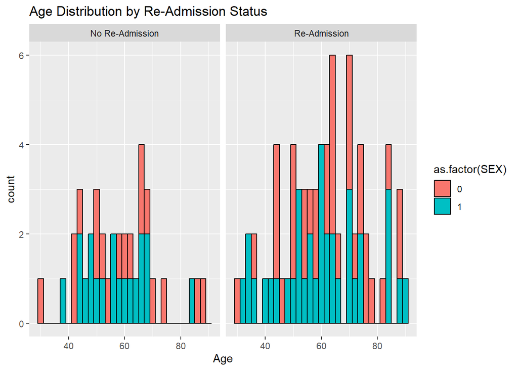

```r
# Histogram
ggplot(data_clean, aes(Age)) +
  geom_histogram(aes(fill = as.factor(SEX)), color = "black", binwidth = 2) +
  facet_wrap(~ Readmitted, labeller = labeller(Readmitted = c('0' = "No Re-Admission", '1' = "Re-Admission"))) +
  ggtitle("Age Distribution by Re-Admission Status")
```

## Logistic Regression Models

Logistics regression models were ran. One model using smoking as the only independent variables. Another model using age and sex as the only two independent variables. And a third model that ran with all the independent variables.

```r
# Create regression models
model_smoking <- glm(Readmitted ~ SMOKING, family = binomial, data = data_clean)
model_age_sex <- glm(Readmitted ~ Age + SEX, family = binomial, data = data_clean)
model_full <- glm(Readmitted ~ SMOKING + DRINKING + COMPLIANCE + SURGERY + T2DM + HTN + KidneyDisease + ASTHMACOPD + Dyslipidemia,
                  family = binomial, data = data_clean)


# Model summaries
summary(model_smoking)
```

```
##
## Call:
## glm(formula = Readmitted ~ SMOKING, family = binomial, data = data_clean)
##
## Deviance Residuals:
##     Min       1Q   Median       3Q      Max
## -1.5315  -1.4116   0.8607   0.9600   0.9600
##
## Coefficients:
##             Estimate Std. Error z value Pr(>|z|)
## (Intercept)   0.5355     0.2570   2.084   0.0372 *
## SMOKING1      0.2668     0.4213   0.633   0.5265
## ---
## Signif. codes:  0 '***' 0.001 '**' 0.01 '*' 0.05 '.' 0.1 ' ' 1
##
## (Dispersion parameter for binomial family taken to be 1)
##
##     Null deviance: 137.99  on 106  degrees of freedom
## Residual deviance: 137.58  on 105  degrees of freedom
## AIC: 141.58
##
## Number of Fisher Scoring iterations: 4
```

```r
summary(model_age_sex)
```

```
##
## Call:
## glm(formula = Readmitted ~ Age + SEX, family = binomial, data = data_clean)
##
## Deviance Residuals:
##     Min       1Q   Median       3Q      Max
## -1.6594  -1.3788   0.8432   0.9385   1.1363
##
## Coefficients:
##             Estimate Std. Error z value Pr(>|z|)
## (Intercept) -0.38820    0.91955  -0.422    0.673
## Age          0.01675    0.01438   1.165    0.244
## SEX1         0.04191    0.41065   0.102    0.919
##
## (Dispersion parameter for binomial family taken to be 1)
##
##     Null deviance: 137.99  on 106  degrees of freedom
## Residual deviance: 136.61  on 104  degrees of freedom
## AIC: 142.61
##
## Number of Fisher Scoring iterations: 4
```

```r
summary(model_full)
```

```
##
## Call:
## glm(formula = Readmitted ~ SMOKING + DRINKING + COMPLIANCE +
##     SURGERY + T2DM + HTN + KidneyDisease + ASTHMACOPD + Dyslipidemia,
##     family = binomial, data = data_clean)
##
## Deviance Residuals:
##     Min       1Q   Median       3Q      Max
## -1.9094  -1.2333   0.6788   0.9343   1.4081
##
## Coefficients:
##                Estimate Std. Error z value Pr(>|z|)
## (Intercept)     1.01075    0.65696   1.539   0.1239
## SMOKING1        0.18021    0.53648   0.336   0.7369
## DRINKING1      -0.46411    0.51632  -0.899   0.3687
## COMPLIANCE1    -1.13176    0.49729  -2.276   0.0229 *
## SURGERY1        0.16789    0.45581   0.368   0.7126
## T2DM1           0.86232    0.47570   1.813   0.0699 .
## HTN1           -0.40654    0.59743  -0.680   0.4962
## KidneyDisease1  0.07258    0.51767   0.140   0.8885
## ASTHMACOPD1     0.44174    0.55694   0.793   0.4277
## Dyslipidemia1  -0.17057    0.50344  -0.339   0.7348
## ---
## Signif. codes:  0 '***' 0.001 '**' 0.01 '*' 0.05 '.' 0.1 ' ' 1
##
## (Dispersion parameter for binomial family taken to be 1)
##
##     Null deviance: 137.99  on 106  degrees of freedom
## Residual deviance: 128.72  on  97  degrees of freedom
## AIC: 148.72
##
## Number of Fisher Scoring iterations: 4
```

## Correlation check and model selection

Variance Inflation Factor(vif) was used to quantify the correlation between the independent variables. The vif for each variable was moderate or low and did not indicate multicollinearity.

Stepwise algorithm was used to select the best model based on the AIC.

```r
# Check for multicollinearity
vif(model_full)
```

```
##       SMOKING      DRINKING    COMPLIANCE       SURGERY          T2DM
##      1.503259      1.420182      1.348203      1.150803      1.239310
##           HTN KidneyDisease    ASTHMACOPD  Dyslipidemia
##      1.111446      1.051055      1.063496      1.130762
```

```r
# Stepwise selection
best_model <- stepAIC(model_full, direction = "both")
```

```
## Start:  AIC=148.72
## Readmitted ~ SMOKING + DRINKING + COMPLIANCE + SURGERY + T2DM +
##     HTN + KidneyDisease + ASTHMACOPD + Dyslipidemia
##
##                 Df Deviance    AIC
## - KidneyDisease  1   128.74 146.74
## - SMOKING        1   128.84 146.84
## - Dyslipidemia   1   128.84 146.84
## - SURGERY        1   128.86 146.86
## - HTN            1   129.20 147.20
## - ASTHMACOPD     1   129.37 147.37
## - DRINKING       1   129.54 147.54
## <none>               128.72 148.72
## - T2DM           1   132.15 150.15
## - COMPLIANCE     1   134.13 152.13
##
## Step:  AIC=146.74
## Readmitted ~ SMOKING + DRINKING + COMPLIANCE + SURGERY + T2DM +
##     HTN + ASTHMACOPD + Dyslipidemia
##
##                 Df Deviance    AIC
## - SMOKING        1   128.85 144.85
## - Dyslipidemia   1   128.86 144.86
## - SURGERY        1   128.89 144.89
## - HTN            1   129.21 145.21
## - ASTHMACOPD     1   129.42 145.42
## - DRINKING       1   129.56 145.56
## <none>               128.74 146.74
## - T2DM           1   132.16 148.16
## + KidneyDisease  1   128.72 148.72
## - COMPLIANCE     1   134.17 150.17
##
## Step:  AIC=144.85
## Readmitted ~ DRINKING + COMPLIANCE + SURGERY + T2DM + HTN + ASTHMACOPD +
##     Dyslipidemia
##
##                 Df Deviance    AIC
## - SURGERY        1   128.95 142.95
## - Dyslipidemia   1   128.95 142.95
## - HTN            1   129.30 143.30
```

[output cut: 68 more lines]

```
##
## Step:  AIC=136.78
## Readmitted ~ COMPLIANCE + T2DM
##
##                 Df Deviance    AIC
## <none>               130.78 136.78
## - T2DM           1   133.96 137.96
## + ASTHMACOPD     1   130.02 138.02
## + DRINKING       1   130.40 138.40
## + HTN            1   130.45 138.45
## + Dyslipidemia   1   130.66 138.66
## + SURGERY        1   130.66 138.66
## + KidneyDisease  1   130.75 138.75
## + SMOKING        1   130.78 138.78
## - COMPLIANCE     1   136.51 140.51
```

```r
summary(best_model)
```

```
##
## Call:
## glm(formula = Readmitted ~ COMPLIANCE + T2DM, family = binomial,
##     data = data_clean)
##
## Deviance Residuals:
##     Min       1Q   Median       3Q      Max
## -1.8397  -1.3671   0.6379   0.8955   1.3277
##
## Coefficients:
##             Estimate Std. Error z value Pr(>|z|)
## (Intercept)   0.7067     0.3117   2.267   0.0234 *
## COMPLIANCE1  -1.0533     0.4483  -2.349   0.0188 *
## T2DM1         0.7821     0.4471   1.749   0.0802 .
## ---
## Signif. codes:  0 '***' 0.001 '**' 0.01 '*' 0.05 '.' 0.1 ' ' 1
##
## (Dispersion parameter for binomial family taken to be 1)
##
##     Null deviance: 137.99  on 106  degrees of freedom
## Residual deviance: 130.78  on 104  degrees of freedom
## AIC: 136.78
##
## Number of Fisher Scoring iterations: 4
```

## Regression tables

The first model shown here is the model the algorithm choose as the best model based on the AIC. The second model shown is the full model, with all the independent variables.

```r
tbl_regression(best_model, exponentiate = TRUE) %>%
  bold_p(t = 0.05) %>%
  italicize_levels() %>%
  modify_caption("Multivariate Regression for Re-Admission")
```

Multivariate Regression for Re-Admission

| **Characteristic** | **OR**<sup>1</sup> | **95% CI**<sup>1</sup> | **p-value** |
| --- | --- | --- | --- |
| COMPLIANCE |  |  |  |
| 0 | — | — |  |
| 1 | 0.35 | 0.14, 0.83 | 0.019 |
| T2DM |  |  |  |
| 0 | — | — |  |
| 1 | 2.19 | 0.93, 5.42 | 0.080 |

<sup>1</sup> OR = Odds Ratio, CI = Confidence Interval

```r
tbl_regression(model_full, exponentiate = TRUE) %>%
  bold_p(t = 0.05) %>%
  italicize_levels() %>%
  modify_caption("Multivariate Regression for Re-Admission")
```

Multivariate Regression for Re-Admission

| **Characteristic** | **OR**<sup>1</sup> | **95% CI**<sup>1</sup> | **p-value** |
| --- | --- | --- | --- |
| SMOKING |  |  |  |
| 0 | — | — |  |
| 1 | 1.20 | 0.42, 3.50 | 0.7 |
| DRINKING |  |  |  |
| 0 | — | — |  |
| 1 | 0.63 | 0.22, 1.72 | 0.4 |
| COMPLIANCE |  |  |  |
| 0 | — | — |  |
| 1 | 0.32 | 0.12, 0.84 | 0.023 |
| SURGERY |  |  |  |
| 0 | — | — |  |
| 1 | 1.18 | 0.49, 2.93 | 0.7 |
| T2DM |  |  |  |
| 0 | — | — |  |
| 1 | 2.37 | 0.95, 6.23 | 0.070 |
| HTN |  |  |  |
| 0 | — | — |  |
| 1 | 0.67 | 0.19, 2.08 | 0.5 |
| KidneyDisease |  |  |  |
| 0 | — | — |  |
| 1 | 1.08 | 0.40, 3.08 | 0.9 |
| ASTHMACOPD |  |  |  |
| 0 | — | — |  |
| 1 | 1.56 | 0.54, 4.95 | 0.4 |
| Dyslipidemia |  |  |  |
| 0 | — | — |  |
| 1 | 0.84 | 0.32, 2.31 | 0.7 |

<sup>1</sup> OR = Odds Ratio, CI = Confidence Interval